# Clase 1.2 Datos y dónde encontrarlos

Estadística y Manejo de Datos con R (EMDR) — Virtual

## Bases de datos

## Introducción

- “Era de los Datos”: procesos automatizados generan datos en gran cantidad.
- Hoy, obtener datos es más fácil que saber qué hacer con ellos.
- R ofrece varias bases de datos (pequeñas y grandes) “curadas” para practicar
- También hay excelentes métodos de generación de *mock data*.

## Dónde encontrar datos

## En la red global

- Google data sets (https://toolbox.google.com/datasetsearch)
- 1000 Genomes Project (https://www.internationalgenome.org/) contiene genomas humanos diversos.
- Food and Agriculture Organization (https://www.fao.org/statistics/databases/en/) producción de alimentos y agricultura mundial.
- Department of Transport, UK (https://www.dft.gov.uk/) contiene georeferencias de eventos del tráfico del Reino Unido.
- SIMAT (https://www.aire.cdmx.gob.mx/) monitoreo en tiempo real de los datos de contaminación de la CDMX.
- The Digital Archaeological Data https://core.tdar.org/
- World Bank Open Data https://data.worldbank.org/
- https://www.reddit.com/r/datasets es una comunidad donde se comparten data sets variados.

## En R: `data()`

Con la función `data()` podemos conocer los datos curados que R tiene por defecto.

```r
data()
```

```r
data(Animals, package = "MASS")
head(Animals)
```

```
##                     body brain
## Mountain beaver     1.35   8.1
## Cow               465.00 423.0
## Grey wolf          36.33 119.5
## Goat               27.66 115.0
## Guinea pig          1.04   5.5
## Dipliodocus     11700.00  50.0
```

```r
help(Animals, package = "MASS")
```

## En R: `data()`

```r
head(LifeCycleSavings)
```

```
##              sr pop15 pop75     dpi ddpi
## Australia 11.43 29.35  2.87 2329.68 2.87
## Austria   12.07 23.32  4.41 1507.99 3.93
## Belgium   13.17 23.80  4.43 2108.47 3.82
## Bolivia    5.75 41.89  1.67  189.13 0.22
## Brazil    12.88 42.19  0.83  728.47 4.56
## Canada     8.79 31.72  2.85 2982.88 2.43
```

```r
help(LifeCycleSavings)
```

- Intercountry Life-Cycle Savings Data.
- Data on the savings ratio 1960–1970.
  - A data frame with 50 observations on 5 variables.
    - [,1] sr numeric aggregate personal savings.
    - [,4] dpi numeric real per-capita disposable income.

## En R: `data()`

[figure not shown]

## Bases de datos: *Mock data*

- También es posible generar mock data (datos falsos) para explorar algún aspecto.
- R tiene varias funciones que generan datos aleatorios con distintas distribuciones.
- Únicamente, tenemos que especificar los parámetros estadísticos y las dimensiones de los marcos de datos.

## Bases de datos: *Mock data*

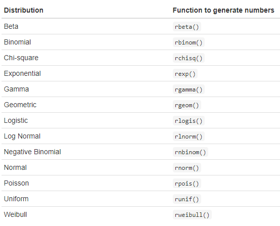

## Bases de datos: *Mock data*

```r
x <- runif(10, min = 0, max = 10)
x
```

```
##  [1] 5.7443774 3.9676058 2.0696649 8.0424371 9.9792133 5.4457259 2.0050145
##  [8] 0.2389672 6.9369555 6.7867221
```

```r
x <- rnorm(10, mean = 10, sd = 0.5)
x
```

```
##  [1]  9.724596  9.432240 10.013471 10.450694 10.882622  9.957986 10.080627
##  [8]  9.711423  9.581355  9.088243
```

```r
x <- rpois(10, lambda = 5)
x
```

```
##  [1]  4  5  5  6  2  1 10  9  6  7
```

## Bases de datos: *Mock data*

- La función sample() equivale a elegir un número de una serie.

```r
x <- sample(1:10, 1)
x
```

```
## [1] 3
```

- O en el caso que permitamos las repeticiones

```r
x <- sample(1:10, 5, replace=TRUE)
x
```

```
## [1] 8 2 7 1 3
```

## Leer y guardar datos

## Bases de datos: Leer y guardar

- Podemos cargar archivos desde una localización local o desde un URL.
- La funcionalidad básica de R permite lectura del formato `.csv`.
- Para otras extensiones (`.xls`,`.xlsx`,`.sav`,`.gpx`, etc) existen paquetes adicionales.
- Es importante explorar los parámetros de estas funciones para leer y guardar datos tal cual los queremos.

## Bases de datos: Leer y guardar

- La función básica para **leer** es `read.table()`

```r
read.table(path_to_filename, header = FALSE, sep = ",", row.names, col.names,
           skip = 0, fill = !blank.lines.skip,
           strip.white = FALSE, blank.lines.skip = TRUE,
           comment.char = "#")
```

- Podemos elegir el caracter que separa las columnas: `","`, `"/t"`, `" "`

## Bases de datos: Leer y guardar

[figure not shown]

## Bases de datos: Leer y guardar

- La función básica para **guardar** es `write.table()`

```r
write.table(x, file = "path_to_filename", append = FALSE, sep = ",",
            row.names = TRUE, col.names = TRUE)
```

## Ejercicios

## Bases de datos: Ejercicios

- Crea un archivo en Excel o en Calc de varias columnas y guárdalo como `.csv`
- Cambiemos al directorio donde está este archivo con `setwd()`
- Carguemos el archivo con `read.table()`
- Modifiquemos el marco de datos y guardemos el archivo con `write.table()`

## Bases de datos: Ejercicios

- Experimenta con distintos argumentos:
  - `read.table(,sep="/t")`
  - `read.table(,header=FALSE)`
  - `write.table(,row.names=FALSE)`
- Si tienes archivos de otro origen (p.e. SPSS), investiga los paquetes y exploralos en este curso.
- Intenta guardar el archivo en un folder distinto a tu *working directory*
- Integra al script en que reportarás tus actividades el código resultante.

## Otros paquetes para leer datos

## Bases de datos: `readxl`

[figure not shown]

## Bases de datos: `readxl`

- Añade funcionalidad para leer archivos `.xls` y `.xlsx` directamente.
- Funciones `read_excel()`, `read_xls()` y `read_xlsx()`

```r
install.packages("readxl")
library(readxl)
read_excel(path_to_filename, sheet = NULL, range = NULL, col_names = TRUE,
  na = "", trim_ws = TRUE, skip = 0)
```

## Bases de datos: `readr`

[figure not shown]

## Bases de datos: `readr`

```r
install.packages("readxl")
library(readr)
read.csv(filename)
```

## La ayuda en R

## Solicitar la ayuda en R

- ¿Cómo?
  - Tecleando en la consola *?función()*, por ejemplo: `?plot()`
- Lo que nos mostrará su descripción y contenidos
  - `función {paquete}`
  - Uso: función(argumento 1, argumento 2, etc.)
  - Argumentos: descripción operativa
  - Detalles
  - Notas
  - Referencias: libros, artículos o enlaces
  - Ver también: funciones relacionadas
  - Ejemplos: ejecutables

## Bases de datos: Exploración

- Después de leer y asignar a un objeto en R los datos, podemos iniciar su exploración.
- Con `head()` y `tail()` podemos conocer la parte superior e inferior del df (marco de datos, por su acrónimo en inglés).
- Con `str()` podemos conocer su estructura y el tipo de datos que contiene.
- Con `summary()` podemos conocer un resumen descriptivo del marco de datos.
- Otro aspecto importante es manipular el df para obtener un subconjunto, separar o juntar columnas, deshacerse de casos o celdas vacías, etc.

## Bases de datos: Cabeza y cola

```r
head(USArrests) # cabeza
```

```
##            Murder Assault UrbanPop Rape
## Alabama      13.2     236       58 21.2
## Alaska       10.0     263       48 44.5
## Arizona       8.1     294       80 31.0
## Arkansas      8.8     190       50 19.5
## California    9.0     276       91 40.6
## Colorado      7.9     204       78 38.7
```

```r
tail(USArrests) # cola
```

```
##               Murder Assault UrbanPop Rape
## Vermont          2.2      48       32 11.2
## Virginia         8.5     156       63 20.7
## Washington       4.0     145       73 26.2
## West Virginia    5.7      81       39  9.3
## Wisconsin        2.6      53       66 10.8
## Wyoming          6.8     161       60 15.6
```

## Bases de datos: Dimensiones

```r
dim(Seatbelts) # filas y columnas
```

```
## [1] 192   8
```

```r
dim(Titanic) # ¿filas y columnas? ¿y/o qué más?
```

```
## [1] 4 2 2 2
```

## Bases de datos: Descripción estructural

- ¿Qué sucede con la estructura de algunos conjuntos de datos?

```r
str(Seatbelts)
```

```
##  Time-Series [1:192, 1:8] from 1969 to 1985: 107 97 102 87 119 106 110 106 107 134 ...
##  - attr(*, "dimnames")=List of 2
##   ..$ : NULL
##   ..$ : chr [1:8] "DriversKilled" "drivers" "front" "rear" ...
```

```r
str(Titanic)
```

```
##  'table' num [1:4, 1:2, 1:2, 1:2] 0 0 35 0 0 0 17 0 118 154 ...
##  - attr(*, "dimnames")=List of 4
##   ..$ Class   : chr [1:4] "1st" "2nd" "3rd" "Crew"
##   ..$ Sex     : chr [1:2] "Male" "Female"
##   ..$ Age     : chr [1:2] "Child" "Adult"
##   ..$ Survived: chr [1:2] "No" "Yes"
```

## Estadística descriptiva en un paso

```r
summary(Titanic)
```

```
## Number of cases in table: 2201
## Number of factors: 4
## Test for independence of all factors:
##  Chisq = 1637.4, df = 25, p-value = 0
##  Chi-squared approximation may be incorrect
```

```r
summary(iris)
```

```
##   Sepal.Length    Sepal.Width     Petal.Length    Petal.Width
##  Min.   :4.300   Min.   :2.000   Min.   :1.000   Min.   :0.100
##  1st Qu.:5.100   1st Qu.:2.800   1st Qu.:1.600   1st Qu.:0.300
##  Median :5.800   Median :3.000   Median :4.350   Median :1.300
##  Mean   :5.843   Mean   :3.057   Mean   :3.758   Mean   :1.199
##  3rd Qu.:6.400   3rd Qu.:3.300   3rd Qu.:5.100   3rd Qu.:1.800
##  Max.   :7.900   Max.   :4.400   Max.   :6.900   Max.   :2.500
##        Species
##  setosa    :50
##  versicolor:50
##  virginica :50
##
##
##
```

## Nombres de las variables (columnas)

```r
names(iris)
```

```
## [1] "Sepal.Length" "Sepal.Width"  "Petal.Length" "Petal.Width"  "Species"
```

```r
# ¿Qué sucede con 'WorldPhones'?
names(WorldPhones)
```

[output not shown]

```r
str(WorldPhones)
```

```
##  num [1:7, 1:7] 45939 60423 64721 68484 71799 ...
##  - attr(*, "dimnames")=List of 2
##   ..$ : chr [1:7] "1951" "1956" "1957" "1958" ...
##   ..$ : chr [1:7] "N.Amer" "Europe" "Asia" "S.Amer" ...
```

```r
colnames(WorldPhones)
```

```
## [1] "N.Amer"   "Europe"   "Asia"     "S.Amer"   "Oceania"  "Africa"   "Mid.Amer"
```

```r
help(iris)
help(WorldPhones)
```

## Ejercicios

## Bases de datos: Ejercicios

- Explora la lista de bases de datos disponibles en R con `data()`
- Elige una o dos que no hayamos revisado en esta cápsula.
- Reporta las características de tu conjunto de datos.
- Emplea `dim()`, `head()`, `str()`
- Indica:
  - Los nombres de las variables o columnas.
  - De dónde provienen los datos y qué representa cada variable.

## Licencia CC BY

Estadística y Manejo de Datos con R (EMDR) por Marcos F. Rosetti S. y Luis Pacheco-Cobos se distribuye bajo una [Licencia Creative Commons Atribución 4.0 Internacional](http://creativecommons.org/licenses/by/4.0/).